# Tutorial: Analyzing Adverse Events Associated with COVID-19 Vaccines

## Motivation

Since the beginning of 2020 when COVID-19 started becoming a widespread disease around the world, the lives of many have been greatly impacted. COVID-19 not only impaired our mental and physical health, but also destructed the economy and affected the livings of many people. After the world has been combating COVID-19 for about a year, the emergence of COVID-19 vaccines seem like a ray of hope for stopping the disease. According to the Center for Disease Control and Prevention (CDC), studies have shown the effectivenss of mRNA vaccines (Pfizer-BioNTech and Moderna) to be 94%. While many people are ready to get vaccinated, some people are more reserved as they worry about the possible side effects associated with the vaccines. As there have been reports about the adverse events associated with COVID-19 vaccines, I think this would be a great topic worth exploring. The purpose of the analysis is to allow the readers to better understand the risks associated with the vaccines and to possibly identify the groups of people who are more prone to the adverse side effects. This tutorial is going to walk you through the data science pipeline to perform such analysis.

Disclaimer: This tutorial is in no way discouraging getting vaccinationed for COVID-19 as many studies have proven the benefits of getting vaccinated. The purpose of this analysis is only to provide a better understanding of the adverse events associated with the COVID-19 vaccines. learn more about COVID-19 vaccines: https://www.cdc.gov/coronavirus/2019-ncov/vaccines/index.html

## Before we start: Library

Before we begin our data science journey, we will first import all the library that will be used in this tutorial. Below is the list of all the library that are used and links to further explore each of them.

- Pandas: organize data into dataframes (https://pandas.pydata.org/docs/)
- NumPy: create multidimensional arrays (https://numpy.org/doc/stable/user/whatisnumpy.html)
- Matplotlib: visualize data and produce plots (https://matplotlib.org/)
- seaborn: data visualization and plotting (https://seaborn.pydata.org/)
- re: regular expression (https://docs.python.org/3/library/re.html)
- scikit-learn: train regression models using data (https://scikit-learn.org/stable/)
- datatime: create objects to present date and time (https://docs.python.org/3/library/datetime.html)
- statsmodels: perform t-test on model fitting result (https://www.statsmodels.org/stable/index.html)

```python
import pandas as pd
pd.options.mode.chained_assignment = None
import numpy as np
import matplotlib.pyplot as plt
import seaborn as sns
import re
from sklearn import linear_model
import datetime
import statsmodels.api as sm
```

## 1. Data Collection

### About the data

The data for this tutorial is retrieved from the Vaccine Adverse Event Reporting System (VAERS), which is cosponsored by the CDC and the Food and Drug Administration (FDA). https://vaers.hhs.gov/data/datasets.html. The system receives reports of adverse events associated with vaccines from doctors and vaccine providers. An important note about the data is that "no cause and effect relationship has been established for any reported event." Therefore, the data should only be providing us with possible correlations. The data provides reports of individuals who experienced adverse events associated with vaccines in 2021. To read more about the data use guide: https://vaers.hhs.gov/docs/VAERSDataUseGuide_November2020.pdf

### 1.1 loading and previewing the data

Since the data is provided in three separate csv files, we need to load each file individually. Here, we are using the pandas read_csv function to achieve this.

```python
with open('2021VAERSDATA.csv', encoding="cp1252") as csv_file:
    data = pd.read_csv(csv_file, low_memory = False)

with open('2021VAERSSYMPTOMS.csv', encoding="cp1252") as csv_file:
    symptoms = pd.read_csv(csv_file, low_memory = False)

with open('2021VAERSVAX.csv', encoding="cp1252") as csv_file:
    vaccines = pd.read_csv(csv_file, low_memory = False)

display(data.head())
display(symptoms.head())
display(vaccines.head())
```

|  | VAERS_ID | RECVDATE | STATE | AGE_YRS | CAGE_YR | CAGE_MO | SEX | RPT_DATE | SYMPTOM_TEXT | DIED | DATEDIED | L_THREAT | ER_VISIT | HOSPITAL | HOSPDAYS | X_STAY | DISABLE | RECOVD | VAX_DATE | ONSET_DATE | NUMDAYS | LAB_DATA | V_ADMINBY | V_FUNDBY | OTHER_MEDS | CUR_ILL | HISTORY | PRIOR_VAX | SPLTTYPE | … |
| --- | --- | --- | --- | --- | --- | --- | --- | --- | --- | --- | --- | --- | --- | --- | --- | --- | --- | --- | --- | --- | --- | --- | --- | --- | --- | --- | --- | --- | --- | --- |
| 0 | 916600 | 01/01/2021 | TX | 33.0 | 33.0 | NaN | F | NaN | Right side of epiglottis swelled up and hinder... | NaN | NaN | NaN | NaN | NaN | NaN | NaN | NaN | Y | 12/28/2020 | 12/30/2020 | 2 | None | PVT | NaN | None | None | None | NaN | NaN | … |
| 1 | 916601 | 01/01/2021 | CA | 73.0 | 73.0 | NaN | F | NaN | Approximately 30 min post vaccination administ... | NaN | NaN | NaN | NaN | NaN | NaN | NaN | NaN | Y | 12/31/2020 | 12/31/2020 | 0 | NaN | SEN | NaN | Patient residing at nursing facility. See pati... | Patient residing at nursing facility. See pati... | Patient residing at nursing facility. See pati... | NaN | NaN | … |
| 2 | 916602 | 01/01/2021 | WA | 23.0 | 23.0 | NaN | F | NaN | About 15 minutes after receiving the vaccine, ... | NaN | NaN | NaN | NaN | NaN | NaN | NaN | NaN | U | 12/31/2020 | 12/31/2020 | 0 | NaN | SEN | NaN | None | None | None | NaN | NaN | … |
| 3 | 916603 | 01/01/2021 | WA | 58.0 | 58.0 | NaN | F | NaN | extreme fatigue, dizziness,. could not lift my... | NaN | NaN | NaN | NaN | NaN | NaN | NaN | NaN | Y | 12/23/2020 | 12/23/2020 | 0 | none | WRK | NaN | none | kidney infection | diverticulitis, mitral valve prolapse, osteoar... | got measles from measel shot, mums from mumps ... | NaN | … |
| 4 | 916604 | 01/01/2021 | TX | 47.0 | 47.0 | NaN | F | NaN | Injection site swelling, redness, warm to the ... | NaN | NaN | NaN | NaN | NaN | NaN | NaN | NaN | N | 12/22/2020 | 12/29/2020 | 7 | NaN | PUB | NaN | Na | Na | NaN | NaN | NaN | … |

|  | VAERS_ID | SYMPTOM1 | SYMPTOMVERSION1 | SYMPTOM2 | SYMPTOMVERSION2 | SYMPTOM3 | SYMPTOMVERSION3 | SYMPTOM4 | SYMPTOMVERSION4 | SYMPTOM5 | SYMPTOMVERSION5 |
| --- | --- | --- | --- | --- | --- | --- | --- | --- | --- | --- | --- |
| 0 | 916600 | Dysphagia | 23.1 | Epiglottitis | 23.1 | NaN | NaN | NaN | NaN | NaN | NaN |
| 1 | 916601 | Anxiety | 23.1 | Dyspnoea | 23.1 | NaN | NaN | NaN | NaN | NaN | NaN |
| 2 | 916602 | Chest discomfort | 23.1 | Dysphagia | 23.1 | Pain in extremity | 23.1 | Visual impairment | 23.1 | NaN | NaN |
| 3 | 916603 | Dizziness | 23.1 | Fatigue | 23.1 | Mobility decreased | 23.1 | NaN | NaN | NaN | NaN |
| 4 | 916604 | Injection site erythema | 23.1 | Injection site pruritus | 23.1 | Injection site swelling | 23.1 | Injection site warmth | 23.1 | NaN | NaN |

|  | VAERS_ID | VAX_TYPE | VAX_MANU | VAX_LOT | VAX_DOSE_SERIES | VAX_ROUTE | VAX_SITE | VAX_NAME |
| --- | --- | --- | --- | --- | --- | --- | --- | --- |
| 0 | 916600 | COVID19 | MODERNA | 037K20A | 1 | IM | LA | COVID19 (COVID19 (MODERNA)) |
| 1 | 916601 | COVID19 | MODERNA | 025L20A | 1 | IM | RA | COVID19 (COVID19 (MODERNA)) |
| 2 | 916602 | COVID19 | PFIZER\BIONTECH | EL1284 | 1 | IM | LA | COVID19 (COVID19 (PFIZER-BIONTECH)) |
| 3 | 916603 | COVID19 | MODERNA | unknown | UNK | NaN | NaN | COVID19 (COVID19 (MODERNA)) |
| 4 | 916604 | COVID19 | MODERNA | NaN | 1 | IM | LA | COVID19 (COVID19 (MODERNA)) |

### 1.2 dropping unnecessary columns

Since the data files from VAERS contain a lot of information, after examining what each column represents, I am going to drop columns that will be irrelevent to my analysis. Columns dropped include ones that contain specific information about the report forms and columns that contain textual descriptions of symptoms. Since our analysis will be looking at the general trend of adverse events, classifications for symptoms are used over textual descriptions.

```python
data = data.drop(columns=['SYMPTOM_TEXT','CAGE_YR','CAGE_MO','RPT_DATE','LAB_DATA','V_ADMINBY','V_FUNDBY','SPLTTYPE',
                         'FORM_VERS','TODAYS_DATE'])
symptoms = symptoms.drop(columns = ['SYMPTOMVERSION1','SYMPTOMVERSION2','SYMPTOMVERSION3','SYMPTOMVERSION4','SYMPTOMVERSION5'])
vaccines = vaccines[['VAERS_ID','VAX_TYPE','VAX_MANU','VAX_DOSE_SERIES']]
# Only keep entries for COVID-19 vaccines
vaccines = vaccines[vaccines['VAX_TYPE'] == 'COVID19']
vaccines = vaccines.drop(columns = ['VAX_TYPE'])
```

## 2. Data Management

### 2.1 Dealing with duplicates

Each patient is only identified once by VAERS ID in the dataframe that contains patients's information. However, the other dataframes contain duplicates of VAERS ID representing different doses of vaccines and multiple symptoms of the same patient. Hence, I will remove duplicates in the vaccine dataframe and combine the symptoms of the same patient into one entry in the symptoms dataframe.

```python
# drop duplicates in the vaccines dataframe
vaccines = vaccines.drop(columns=['VAX_DOSE_SERIES'])
vaccines = vaccines.drop_duplicates(subset=['VAERS_ID'])

# concatenate symptoms of the same patient into a list
symptoms = pd.melt(symptoms, id_vars=['VAERS_ID'],
                              value_vars=['SYMPTOM1','SYMPTOM2','SYMPTOM3','SYMPTOM4','SYMPTOM5'])
symptoms = symptoms.dropna(subset=['value'])
symptoms_by_patient= symptoms.groupby('VAERS_ID').agg({'value':lambda x:x.tolist()})
symptoms_by_patient = symptoms_by_patient.reset_index()
symptoms_by_patient.columns = ['VAERS_ID', 'SYMPTOMS']
```

### 2.2 Making decisions from the data

According to studies such as the one from Yale Medicine (https://www.yalemedicine.org/news/covid-19-vaccine-comparison), vaccines from different manufacturers are not the same and may result in very different side effects. Hence, here I decide to only look at events reported for vaccines from a specific manufacturer. To determine the brand of vaccine that we will analyze, we are going to look for manufacturer with the most adverse events reported and use it as the manufacturer for this analysis.

```python
# Count the number of adverse events associated with vaccines from each manufacturer
manu_count = dict()
for index, row in vaccines.iterrows():
    manu = vaccines.at[index,'VAX_MANU']
    if manu not in manu_count:
        manu_count[manu] = 1
    else:
        manu_count[manu] += 1
print(manu_count)
manu = max(manu_count.items(), key=lambda x: x[1])[0]
print('Manufacturer with the most adverse events reported: ' + manu)
# Only leave entries associated with the specific manufacturer
vaccines = vaccines[vaccines['VAX_MANU'] == manu]
```

```
{'MODERNA': 16387, 'PFIZER\\BIONTECH': 16285, 'UNKNOWN MANUFACTURER': 18, 'JANSSEN': 1107}
Manufacturer with the most adverse events reported: MODERNA
```

### 2.3 Merging the dataframes

Now that we have preprocessed each dataframe and decided that we will perform analysis for vaccines provided by **Moderna**, we are going to merge the three dataframes into one. We will also do some processing to ensure that the types of data is in the form that we want.

```python
# Merge the three dataframes based on the VAERS_ID
# This is a inner join, which returns the union of the three dataframes
patients = (data.merge(symptoms_by_patient, on = ['VAERS_ID'])).merge(vaccines, on = ['VAERS_ID'])

# Turn onset_date from strings to pandas datetime objects
for index, row in patients.iterrows():
    onset = patients.at[index, 'ONSET_DATE']
    if not pd.isnull(onset):
        if not re.match("\d+/\d+/\d+", onset):
            patients.at[index, 'ONSET_DATE'] = np.NaN
patients['ONSET_DATE'] = pd.to_datetime(patients['ONSET_DATE'], format='%m/%d/%Y')

# Since some fields in the dataframe seems to be manually filled out,
# a missing value is represented in many different ways.
# Here, we are trying to convert all possible missing values into np.NaN
def check_nan(input):
    input = input.lstrip().lower()
    first_word = input.split(' ', 1)[0]
    if first_word in ['none','n/a','n\\a','na','nan','no','unknown']:
        return True
    else:
        return False
for index, row in patients.iterrows():
    for field in ['OTHER_MEDS','CUR_ILL','HISTORY','ALLERGIES']:
        val = patients.at[index, field]
        if not pd.isnull(val):
            if check_nan(str(val)):
                patients.at[index,field] = np.NaN

display(patients.head())
```

|  | VAERS_ID | RECVDATE | STATE | AGE_YRS | SEX | DIED | DATEDIED | L_THREAT | ER_VISIT | HOSPITAL | HOSPDAYS | X_STAY | DISABLE | RECOVD | VAX_DATE | ONSET_DATE | NUMDAYS | OTHER_MEDS | CUR_ILL | HISTORY | PRIOR_VAX | BIRTH_DEFECT | OFC_VISIT | ER_ED_VISIT | ALLERGIES | SYMPTOMS | VAX_MANU |
| --- | --- | --- | --- | --- | --- | --- | --- | --- | --- | --- | --- | --- | --- | --- | --- | --- | --- | --- | --- | --- | --- | --- | --- | --- | --- | --- | --- |
| 0 | 916600 | 01/01/2021 | TX | 33.0 | F | NaN | NaN | NaN | NaN | NaN | NaN | NaN | NaN | Y | 12/28/2020 | 2020-12-30 | 2 | NaN | NaN | NaN | NaN | NaN | Y | NaN | Pcn and bee venom | [Dysphagia, Epiglottitis] | MODERNA |
| 1 | 916601 | 01/01/2021 | CA | 73.0 | F | NaN | NaN | NaN | NaN | NaN | NaN | NaN | NaN | Y | 12/31/2020 | 2020-12-31 | 0 | Patient residing at nursing facility. See pati... | Patient residing at nursing facility. See pati... | Patient residing at nursing facility. See pati... | NaN | NaN | Y | NaN | "Dairy" | [Anxiety, Dyspnoea] | MODERNA |
| 2 | 916603 | 01/01/2021 | WA | 58.0 | F | NaN | NaN | NaN | NaN | NaN | NaN | NaN | NaN | Y | 12/23/2020 | 2020-12-23 | 0 | NaN | kidney infection | diverticulitis, mitral valve prolapse, osteoar... | got measles from measel shot, mums from mumps ... | NaN | NaN | NaN | Diclofenac, novacaine, lidocaine, pickles, tom... | [Dizziness, Fatigue, Mobility decreased] | MODERNA |
| 3 | 916604 | 01/01/2021 | TX | 47.0 | F | NaN | NaN | NaN | NaN | NaN | NaN | NaN | NaN | N | 12/22/2020 | 2020-12-29 | 7 | NaN | NaN | NaN | NaN | NaN | NaN | NaN | NaN | [Injection site erythema, Injection site pruri... | MODERNA |
| 4 | 916606 | 01/01/2021 | NV | 44.0 | F | NaN | NaN | NaN | NaN | NaN | NaN | NaN | NaN | Y | 12/29/2020 | 2020-12-29 | 0 | NaN | NaN | NaN | NaN | NaN | NaN | NaN | iodine (shellfish) has epipen | [Pharyngeal swelling] | MODERNA |

## 3. Exploratory data analysis

### 3.1 Look for common symptoms

Since there are many possible symptoms from adverse events associated with the vaccine, we want to look for the common symptoms and the frequency for each. Common symptoms here are defined as symptoms with a frequency of more than 1% out of all the possible symptoms.

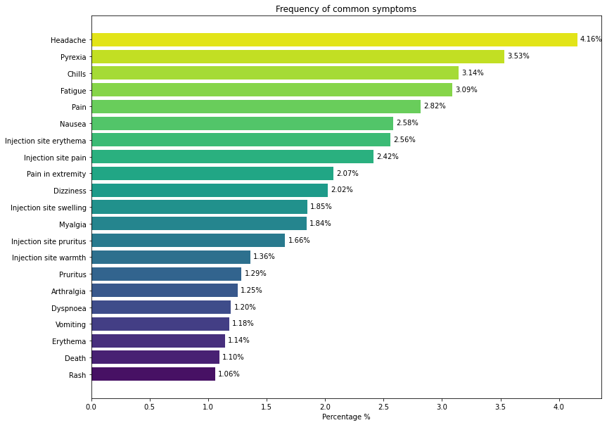

```python
# count the frequency for each symptom
symptom_count = dict()
total_count = 0
for ls in patients['SYMPTOMS']:
    for sym in ls:
        total_count += 1
        if sym not in symptom_count:
            symptom_count[sym] = 1
        else:
            symptom_count[sym] += 1
# collect all common symptoms with percentage higher than 1%
common_syms = dict()
for sym in symptom_count:
    percent = symptom_count[sym]/total_count*100
    if percent > 1:
        common_syms[sym] = percent

common_syms = dict(sorted(common_syms.items(), key=lambda item: item[1]))
# plot a horizontal bar graph to show the frequency of each common symptom
keys = common_syms.keys()
y_pos = np.arange(len(keys))
values = common_syms.values()
fig, ax = plt.subplots(figsize = (13,10))
ax.barh(y_pos, values, color=sns.color_palette("viridis",len(keys)))
ax.set_yticks(y_pos)
ax.set_yticklabels(keys)
ax.set_title("Frequency of common symptoms")
ax.set_xlabel('Percentage %')
for p in ax.patches:
    width = p.get_width()
    plt.text(0.12+p.get_width(), p.get_y()+0.55*p.get_height(),
             '{:1.2f}%'.format(width),
             ha='center', va='center')
plt.show()
```

From the plot we can see that headache is the most common symptom, with a frequency of 4.16%, followed by pyrexia with 3.53%, and then chills with 3.14%. We can also see that death as a result of adverse events has a frequency of 1.10%. However, it is noteworthy that this is out of all adverse events reported but not out of all vaccinated individuals. From the distribution of the different symptoms, we can see that besides the four leading common symptoms, types of symptoms seem to be pretty spread out. Common symptoms have frequency around 1 to 4 percent, while most of the symptoms have frequency below 1%.

### 3.2 Associations with sex and age groups

The next thing that we are going to explore is the association between adverse events and sex and age groups. Sex and age groups are two considerably common classifications in the medical world, and hence might be helpful when searching for patterns. Here, we are going to classify age groups as Child (0-14), Young Adult (15-47), Mid Age (48-63), and Elder (>63). The classifications are based on a study linked here https://bmcneurol.biomedcentral.com/articles/10.1186/s12883-020-01888-w

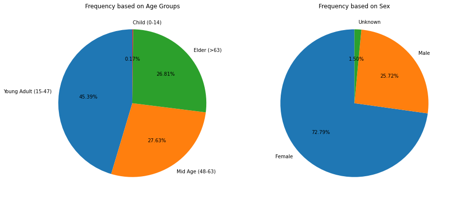

```python
# create bins for each age group
bins= [0,15,48,64,100]
labels = ['Child (0-14)', 'Young Adult (15-47)','Mid Age (48-63)','Elder (>63)']
patients['AgeGroup'] = pd.cut(patients['AGE_YRS'], bins=bins, labels=labels, right=False)

# count the number of patients of each sex and in each age group
age_group_chart = dict(patients['AgeGroup'].value_counts())
gender_chart = dict(patients['SEX'].value_counts())

plt.figure(figsize = (15,10))
ax1 = plt.subplot(1, 2, 1)
ax2 = plt.subplot(1, 2, 2)
ax1.pie(age_group_chart.values(), labels=age_group_chart.keys(), autopct='%1.2f%%',startangle=90)
ax1.set_title("Frequency based on Age Groups")
ax2.pie(gender_chart.values(), labels=['Female','Male','Unknown'], autopct='%1.2f%%',startangle=90)
ax2.set_title("Frequency based on Sex")
plt.show()
```

From the pie chart based on age groups, we can see that 45.39% of patients are young adults. This is quite surprising, as many might expect older individuals to be more prone to adverse events. One possible explanation might be that young adults have stronger immune system and hence react more strongly to vaccines. Another possible explanation is that young adults make up a large portion of vaccinated individuals and hence resulted in more adverse events. Elders and mid age individuals make up about the same percentage, one with 26.81% and the other with 27.63%. From the pie chart based on sex, we can tell that females take up a significantly larger portion with 72.79%. This might suggest that females are more prone to adverse events associated with the Moderna COVID-19 vaccine.

### 3.3 Associations with sex and age groups conditioned on time

From the previous exploratory analysis, we see that age groups and sex could possibly affect the number of patients who have experienced adverse events. Hence, we want to explore whether this is true by plotting the number of patients conditioned on time, age groups, and sex. Here we are trying find out how the different classifications (age groups, sex) might affect the number of patients across time.

```python
# Since we are conditioning on sex, onset_date (time), and age group, we want to
# drop all entries that have missing values in these fields
patients = patients.dropna(subset = ['SEX','ONSET_DATE','AgeGroup'])
patients = patients[patients['SEX'].eq('F')|patients['SEX'].eq('M')]
patients = patients[(patients['ONSET_DATE'].dt.year == 2021)]
# Since date could be too specific as a time range and could be prone to many external factors,
# such as mass vaccination on a certain day, we are going to use month as our time range.
patients['ONSET_DATE'] = patients['ONSET_DATE'].apply(lambda s: datetime.date(s.year, s.month, 1))

groups = patients.copy()
# group data by AgeGroup, sex, and onset_set and count the number of patients in each group
groups = groups.groupby(['AgeGroup','SEX','ONSET_DATE'], as_index = False).agg('count')
groups['ONSET_DATE'] = groups['ONSET_DATE'].map(lambda x: x.strftime('%m-%Y'))
groups['AgeGroup'] = groups.agg('{0[AgeGroup]}_{0[SEX]}'.format, axis=1)
groups = groups[['AgeGroup','ONSET_DATE','VAERS_ID']]
# reshape the dataframe to have classifications as columns for plotting purposes
groups = groups.pivot(index = 'ONSET_DATE', columns = 'AgeGroup', values = 'VAERS_ID')
groups
```

| AgeGroup ONSET_DATE | Child (0-14)_F | Child (0-14)_M | Elder (>63)_F | Elder (>63)_M | Mid Age (48-63)_F | Mid Age (48-63)_M | Young Adult (15-47)_F | Young Adult (15-47)_M |
| --- | --- | --- | --- | --- | --- | --- | --- | --- |
| 01-2021 | 4.0 | 2.0 | 895.0 | 595.0 | 1785.0 | 484.0 | 3509.0 | 679.0 |
| 02-2021 | NaN | NaN | 1217.0 | 763.0 | 508.0 | 176.0 | 663.0 | 184.0 |
| 03-2021 | NaN | NaN | 127.0 | 136.0 | 25.0 | 26.0 | 27.0 | 14.0 |

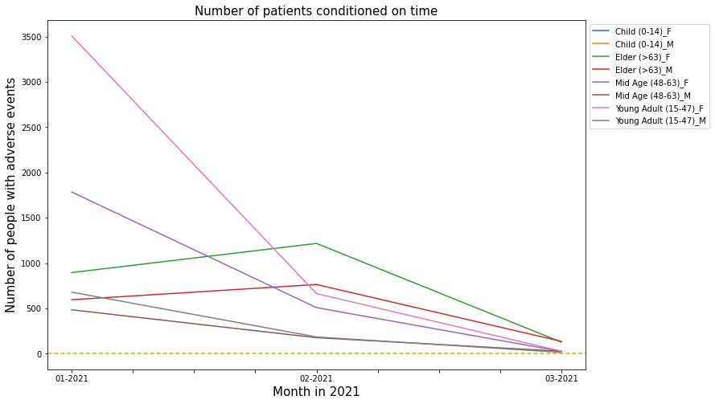

```python
# plot the dataframe with each classification group as a line
plt.figure()
groups.plot(figsize=(12,8))
plt.axhline(y = 0, color = 'y', linestyle = '--')
plt.legend(loc='upper left', bbox_to_anchor=(1,1))
plt.xlabel("Month in 2021", fontsize=15)
plt.ylabel("Number of people with adverse events", fontsize=15)
plt.title("Number of patients conditioned on time", fontsize = 15)
plt.show()
```

From the plot we can see that the classifications seem to have an effect on the trend of the number of patients across time. In general, we can see that there is a decreasing trend for the number of people with adverse events across time. We can also see that the age groups seem to create different trends for the plot. For each age group, we can also observe that the trends of male and female are similar and that the trend for female is almost always higher than that of male.

## 4. Hypothesis testing and machine learning

### 4.1 Linear Regression

From the exploratory data analysis, we observed that sex, age groups, and time seem to have effects on the number of patients with adverse events. Here I form the hypothesis that sex, age groups, and time have linear relationships with the number of patients. We will set the significance level to be 0.05. We are going to build and train a linear regression model using these three terms to test our hypothesis. We choose to use linear regression here because we want to find a more simple and general trend for the relationship. While a polynomial regression might result in better predictive power, it is also more prone to overfitting.

```python
# Splitting our data into two equal sets, a training set and a testing set
shuffled = patients.sample(frac=1)
result = np.array_split(shuffled, 2)

train_set = result[0]
test_set = result[1]
for idx, dataset in enumerate([train_set, test_set]):
    dataset = dataset.groupby(['AgeGroup','SEX','ONSET_DATE'], as_index = False).agg('count')
    dataset = dataset[['AgeGroup','SEX','ONSET_DATE','VAERS_ID']]
    age_group = pd.get_dummies(dataset.AgeGroup, drop_first = True)
    sex = pd.get_dummies(dataset.SEX, drop_first = True)
    standard = dataset[['ONSET_DATE','VAERS_ID']]
    combined = pd.concat([standard, age_group, sex], axis = 1)
    combined['VAERS_ID'] = combined['VAERS_ID'].fillna(0.0)
    combined = combined.rename({'VAERS_ID': 'count'}, axis=1)
    combined['ONSET_DATE'] = combined['ONSET_DATE'].map(lambda x: x.month)
    if idx == 0:
        train_set = combined
    else:
        test_set = combined
```

```python
# Fit a regression model
ind = train_set.drop(['count'], axis = 1)
dep = train_set['count']
lm1 = linear_model.LinearRegression()
reg1 = lm1.fit(ind, dep)

# Using statsmodel to generate p-values of the parameters
x = ind
y = dep
x = sm.add_constant(x)
model = sm.OLS(y,x)
result = model.fit()
print(result.summary())
```

```
                            OLS Regression Results
==============================================================================
Dep. Variable:                  count   R-squared:                       0.515
Model:                            OLS   Adj. R-squared:                  0.380
Method:                 Least Squares   F-statistic:                     3.817
Date:                Mon, 17 May 2021   Prob (F-statistic):             0.0156
Time:                        18:34:38   Log-Likelihood:                -168.17
No. Observations:                  24   AIC:                             348.3
Df Residuals:                      18   BIC:                             355.4
Df Model:                           5
Covariance Type:            nonrobust
=======================================================================================
                          coef    std err          t      P>|t|      [0.025      0.975]
---------------------------------------------------------------------------------------
const                 595.3750    208.871      2.850      0.011     156.553    1034.197
ONSET_DATE           -239.3125     77.131     -3.103      0.006    -401.358     -77.267
Young Adult (15-47)   420.5000    178.126      2.361      0.030      46.271     794.729
Mid Age (48-63)       247.5000    178.126      1.389      0.182    -126.729     621.729
Elder (>63)           315.6667    178.126      1.772      0.093     -58.562     689.896
M                    -232.8333    125.954     -1.849      0.081    -497.453      31.786
==============================================================================
Omnibus:                       21.974   Durbin-Watson:                   1.629
Prob(Omnibus):                  0.000   Jarque-Bera (JB):               32.366
Skew:                           1.849   Prob(JB):                     9.37e-08
Kurtosis:                       7.322   Cond. No.                         11.2
==============================================================================

Notes:
[1] Standard Errors assume that the covariance matrix of the errors is correctly specified.
```

```python
# Predicting using the training set and the testing set to calculate the predictive power
train_set_score = reg1.score(ind, dep)
print('Accuracy of the traning set = ' + str(train_set_score))

ind_test = test_set.drop(['count'], axis = 1)
dep_test = test_set['count']
test_set_score = reg1.score(ind_test, dep_test)
print('Accuracy of the test set = ' + str(test_set_score))
```

```
Accuracy of the traning set = 0.5146134951270152
Accuracy of the test set = 0.49420062620310434
```

From our hypothesis, we know that the null hypothesis states that the parameters have no relationship. Based on the t-test result, we can see that the p-values for ONSET_DATE and Young Adult are all below 0.05. Since we set the significance level to be 0.05, we would hence reject the null hypothesis and conclude that the parameters ONSET_DATE (which represent time) and Young Adult have a linear relationship with the dependent variable, which is the number of patients. However, the p-values for Mid Age, Elder, and M (male) are all greater than 0.05. We will not reject the null hypothesis and thus cannot conclude that they have a linear relationship with the number of patients. By predicting using the training set and the testing set, we can see that they have similar accuracy, which shows that the model does not overfit. However, the accuracy is only around 0.50, which does not provide a good predictive power.

### 4.2 Linear Regression with Interaction Terms

Our previous attempt on looking for a linear regression was not very successful. So let's try another way that might improve our model. From the 'Number of patients conditioned on time' graph that we created earlier, we can see that it seems like age groups have an effect on changing the trend of the the dependent variable. Hence, adding interaction terms for age groups and time might be able to make the model better.

```python
# calculate the interaction between each age group and ONSET_DATE(time)
# and store the values in new columns
for age in ['Young Adult (15-47)','Mid Age (48-63)','Elder (>63)']:
    train_set['month*'+age] = train_set[age]*train_set['ONSET_DATE']
# Fit a regression model
ind_interaction = train_set.drop(['count'], axis = 1)
dep = train_set['count']
lm2 = linear_model.LinearRegression()
reg2 = lm2.fit(ind_interaction, dep)

# Using statsmodel to generate p-values of the parameters
x = ind_interaction
y = dep
x = sm.add_constant(x)
model = sm.OLS(y,x)
result = model.fit()
print(result.summary())
```

```
                            OLS Regression Results
==============================================================================
Dep. Variable:                  count   R-squared:                       0.673
Model:                            OLS   Adj. R-squared:                  0.499
Method:                 Least Squares   F-statistic:                     3.858
Date:                Mon, 17 May 2021   Prob (F-statistic):             0.0117
Time:                        18:55:38   Log-Likelihood:                -163.43
No. Observations:                  24   AIC:                             344.9
Df Residuals:                      15   BIC:                             355.5
Df Model:                           8
Covariance Type:            nonrobust
=============================================================================================
                                coef    std err          t      P>|t|      [0.025      0.975]
---------------------------------------------------------------------------------------------
const                       117.7500    304.957      0.386      0.705    -532.251     767.751
ONSET_DATE                   -0.5000    138.713     -0.004      0.997    -296.159     295.159
Young Adult (15-47)        1451.0000    423.774      3.424      0.004     547.747    2354.253
Mid Age (48-63)             793.0000    423.774      1.871      0.081    -110.253    1696.253
Elder (>63)                 650.1667    423.774      1.534      0.146    -253.086    1553.420
M                          -232.8333    113.258     -2.056      0.058    -474.238       8.571
month*Young Adult (15-47)  -515.2500    196.169     -2.627      0.019    -933.375     -97.125
month*Mid Age (48-63)      -272.7500    196.169     -1.390      0.185    -690.875     145.375
month*Elder (>63)          -167.2500    196.169     -0.853      0.407    -585.375     250.875
==============================================================================
Omnibus:                        8.481   Durbin-Watson:                   1.980
Prob(Omnibus):                  0.014   Jarque-Bera (JB):                7.070
Skew:                           0.846   Prob(JB):                       0.0292
Kurtosis:                       5.050   Cond. No.                         33.1
==============================================================================

Notes:
[1] Standard Errors assume that the covariance matrix of the errors is correctly specified.
```

```python
# Predicting using the training set and the testing set to calculate the predictive power
train_set_score = reg2.score(ind_interaction, dep)
print('Accuracy of the traning set = ' + str(train_set_score))

for age in ['Young Adult (15-47)','Mid Age (48-63)','Elder (>63)']:
    test_set['month*'+age] = test_set[age]*test_set['ONSET_DATE']
test_ind_interaction = test_set.drop(['count'], axis = 1)
test_dep = test_set['count']
test_set_score = reg2.score(test_ind_interaction, test_dep)
print('Accuracy of the test set = ' + str(test_set_score))
```

```
Accuracy of the traning set = 0.6729438514996634
Accuracy of the test set = 0.654434163739847
```

Based on the t-test result, we can see that the p-values for Young Adult, M (Male), and month_Young Adult are all below or around 0.05. If we loosly consider our significance level to be 0.05, we would reject the null hypothesis for no relationship and conclude that the parameters for Young Adult, M (Male), and month*Young Adult have a linear relationship with the dependent variable. By predicting using the training set and the testing set, we can see that they again have similar accuracy, which tells us that the model is not overfitting. The accuracy for the model with interaction terms is around 0.66, which is slightly higher than the accuracy for the model without interaction terms.

From traning a linear regression both with and without interaction terms, we can see that the models do not fully support our hypothesis that sex, age groups, and time have linear relationships with the number of patients. However, we still observed that the parameter 'Young Adult' seems to have a pretty strong relationship with the number of patients in both models and that 'M' (representing sex) has a weak relationship with the number of patients in the model with interaction terms. We also learned that adding interaction terms help improve the predictive power of the linear regression model.

## 5. Conclusion

This tutorial walks through the data science pipline of data collection, data management, exploratory data analysis, and hypothesis testing and machine learning. Insights about each step in also communicated throughout the tutorial. As a recap, we first read in the csv files and drop the unncessary columns. Then, we pre-process the dataframes to fit our need and then merge the three into one. Then, in exploratory data analysis, we explore how different classifications might affect the number of patients who experience adverse events. We then form a hypothesis that sex, age group, and time have linear relationships with the number of patients. We train linear regression models with and without interaction terms using the training set and the testing set to test our hypothesis. While our analysis do not support our hypothesis, we have gain insights on how the classifications (sex, age groups, and time) might affect the number of patients with adverse events.

I hope you enjoy this tutorial. Below are more resources for each step of the data science pipeline.

- data management and data structure: https://pandas.pydata.org/pandas-docs/stable/user_guide/dsintro.html
- Plotting with pandas: https://realpython.com/pandas-plot-python/
- plotting with Matplotlib: https://matplotlib.org/stable/tutorials/introductory/pyplot.html
- exploratory data analysis strategies: https://r4ds.had.co.nz/exploratory-data-analysis.html
- sklearn linear regression: https://scikit-learn.org/stable/modules/generated/sklearn.linear_model.LinearRegression.html
- sklearn polynomial regression: https://scikit-learn.org/stable/modules/generated/sklearn.preprocessing.PolynomialFeatures.html